# Threat Modeling Report

Created on 10/25/2020 1:32:45 PM

**Threat Model Name:**

**Owner:**

**Reviewer:**

**Contributors:**

**Description:**

**Assumptions:**

**External Dependencies:**

### Threat Model Summary:

| Not Started | 0 |
| --- | --- |
| Not Applicable | 0 |
| Needs Investigation | 0 |
| Mitigation Implemented | 23 |
| Total | 23 |
| Total Migrated | 0 |

## Diagram: Diagram 1

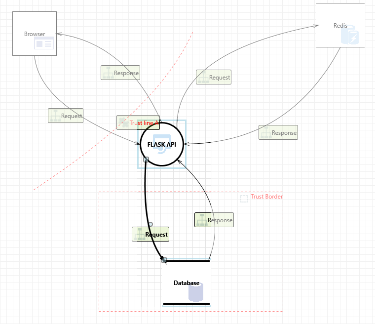

### Diagram 1 Diagram Summary:

| Not Started | 0 |
| --- | --- |
| Not Applicable | 0 |
| Needs Investigation | 0 |
| Mitigation Implemented | 23 |
| Total | 23 |
| Total Migrated | 0 |

### Interaction: Request

[figure not shown]

#### 1. An adversary may gain unauthorized access to Web API due to poor access control checks [State: Mitigation Implemented] [Priority: High]

[output not shown]

#### 2. An adversary can gain access to sensitive information from an API through error messages [State: Mitigation Implemented] [Priority: High]

[output not shown]

#### 3. An adversary may retrieve sensitive data (e.g, auth tokens) persisted in browser storage [State: Mitigation Implemented] [Priority: High]

[output not shown]

#### 4. An adversary can gain access to sensitive data by sniffing traffic to Web API [State: Mitigation Implemented] [Priority: High]

[output not shown]

#### 5. An adversary can gain access to sensitive data stored in Web API's config files [State: Mitigation Implemented] [Priority: Medium]

[output not shown]

#### 6. An adversary may inject malicious inputs into an API and affect downstream processes [State: Mitigation Implemented] [Priority: High]

[output not shown]

#### 7. An adversary can gain access to sensitive data by performing SQL injection through Web API [State: Mitigation Implemented] [Priority: High]

[output not shown]

### Interaction: Request

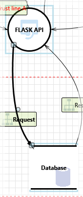

#### 8. An adversary can gain unauthorized access to database due to lack of network access protection [State: Mitigation Implemented] [Priority: High]

[output not shown]

#### 9. An adversary can gain unauthorized access to database due to loose authorization rules [State: Mitigation Implemented] [Priority: High]

[output not shown]

#### 10. An adversary can gain access to sensitive data by performing SQL injection [State: Mitigation Implemented] [Priority: High]

[output not shown]

#### 11. An adversary can gain access to sensitive PII or HBI data in database [State: Mitigation Implemented] [Priority: High]

[output not shown]

### Interaction: Request

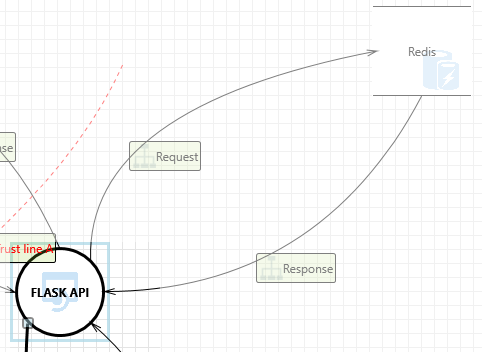

#### 12. An adversary can read sensitive data by sniffing traffic to Redis [State: Mitigation Implemented] [Priority: High]

[output not shown]

### Interaction: Response

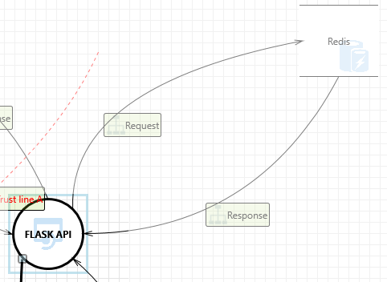

#### 13. An adversary can gain access to sensitive data by performing SQL injection through Web API [State: Mitigation Implemented] [Priority: High]

[output not shown]

#### 14. An adversary may inject malicious inputs into an API and affect downstream processes [State: Mitigation Implemented] [Priority: High]

[output not shown]

#### 15. An adversary can gain access to sensitive data stored in Web API's config files [State: Mitigation Implemented] [Priority: Medium]

[output not shown]

#### 16. An adversary can gain access to sensitive information from an API through error messages [State: Mitigation Implemented] [Priority: High]

[output not shown]

#### 17. An adversary may gain unauthorized access to Web API due to poor access control checks [State: Mitigation Implemented] [Priority: High]

[output not shown]

### Interaction: Response

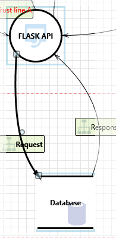

#### 18. An adversary can gain access to sensitive data by performing SQL injection through Web API [State: Mitigation Implemented] [Priority: High]

[output not shown]

#### 19. An adversary may inject malicious inputs into an API and affect downstream processes [State: Mitigation Implemented] [Priority: High]

[output not shown]

#### 20. An adversary can gain access to sensitive data stored in Web API's config files [State: Mitigation Implemented] [Priority: Medium]

[output not shown]

#### 21. An adversary can gain access to sensitive data by sniffing traffic to Web API [State: Mitigation Implemented] [Priority: High]

[output not shown]

#### 22. An adversary can gain access to sensitive information from an API through error messages [State: Mitigation Implemented] [Priority: High]

[output not shown]

#### 23. An adversary may gain unauthorized access to Web API due to poor access control checks [State: Mitigation Implemented] [Priority: High]

[output not shown]